# Week 2 - Part 3: Visualizing Distribution (Fundamentals of dataVis: Chapter 7)

Dr. Donghyung Lee - Modified by Dr. Ashouri

February 10, 2025

# Load Packages

```r
library(tidyverse)
```

# 1. Histograms

- An approximate representation of the distribution of numerical data.
- It is used to analyze a continuous variable (quantitative variable) by grouping the data into intervals (bins).
- The x-axis represents the intervals, while the y-axis shows the frequency or count of data points within each interval.
- Helps to identify patterns, such as the shape of the data distribution (e.g., normal, skewed, or uniform), and highlights outliers or trends.
- https://ggplot2.tidyverse.org/reference/geom_histogram.html

## 1.1 geom_histogram()

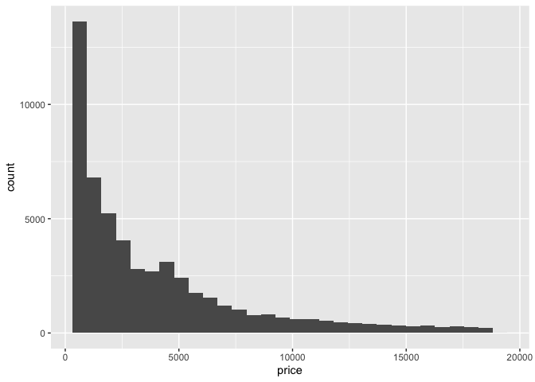

```r
?geom_histogram
ggplot() +
  geom_histogram(aes(x=price), data=diamonds)
```

```r
# Note: `bins=30` is the default.
```

## 1.2 Change color/binwidth

- Adjusting Bins: You can customize the number of bins using the `bins` argument or set a specific width for the bins using the `binwidth` argument.
- Styling: Use the color argument to set the outline color of the bars and the fill argument to specify the fill color inside the bars.

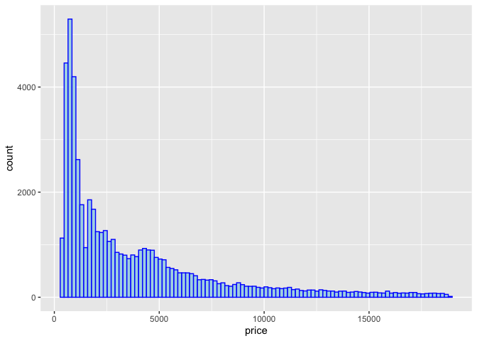

```r
ggplot() +
  geom_histogram(aes(x=price), color="blue", fill="lightblue" , data=diamonds,
                 bins=100)
```

### 1.2.1 Use “fill” instead of “color”

- color: control the outline or border color of geometric shapes - When specified outside `aes()`, it applies a single, fixed color to all elements.
- fill: control the interior color of closed geometric shapes - When specified outside `aes()`, it applies a single, fixed color to all elements.

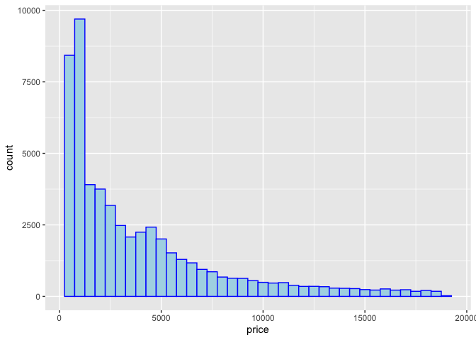

```r
ggplot() +
  geom_histogram(aes(x=price), color="blue", fill="lightblue", data=diamonds,
                 binwidth = 500)
```

### 1.2.2 Change the binwidth

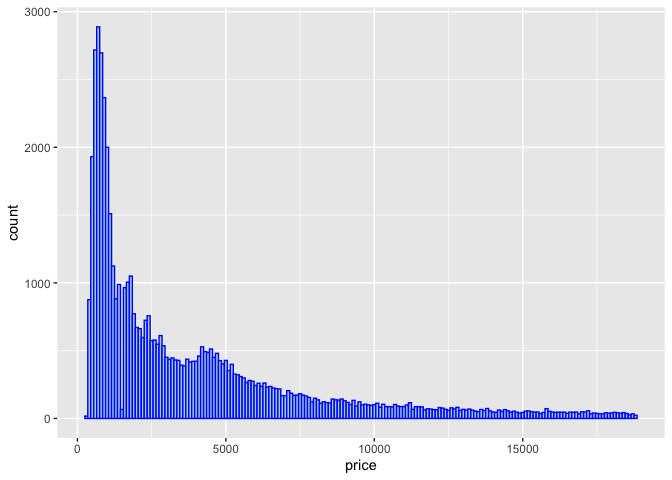

```r
ggplot() +
  geom_histogram(aes(x=price), color="blue", fill="lightblue", data=diamonds,
                 binwidth = 100)
```

### 1.2.3 Change the number of bins

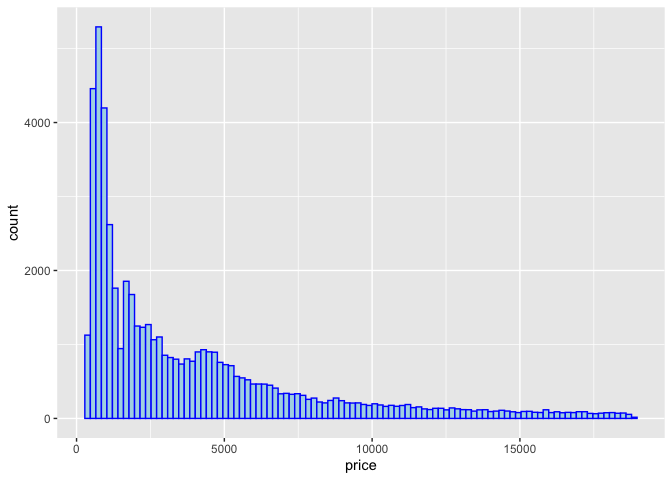

```r
ggplot() +
  geom_histogram(aes(x=price), color="blue", fill="lightblue", data=diamonds,
                 bins=100)
```

### 1.2.4 “fill” mapping inside aes()

- `fill` Mapping in `aes()`: The `fill` aesthetic inside `aes()` is used to map a variable to the fill color of elements, such as bars in a histogram.
- Follow a similar rule as `color` when specifying aesthetic options inside and outside `aes()`

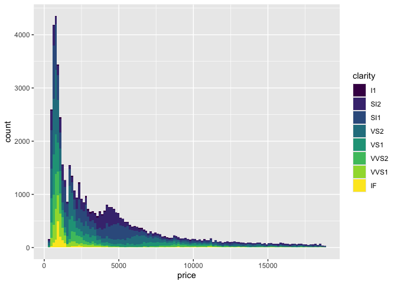

```r
ggplot()+
  geom_histogram(aes(x=price, fill=clarity),
                bins=120, data=diamonds)
```

### 1.2.5 Use `facet_grid()` vertical direction

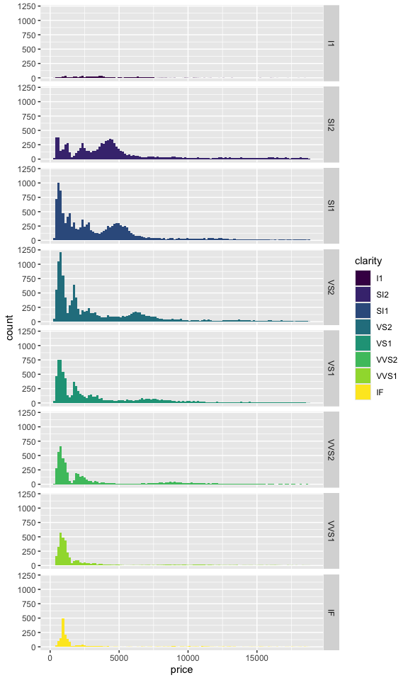

```r
ggplot()+
  geom_histogram(aes(x=price, fill=clarity),
                 bins=120, data=diamonds) +
  facet_grid(clarity~.)
```

# 2. Density Plots

- What is the density function? it represents the probability distribution of a continuous random variable, illustrating how values are distributed across the range of possible outcomes.
- Density plots are smoother versions of histograms, providing a continuous curve to visualize the underlying distribution of the data.
- https://en.wikipedia.org/wiki/Probability_density_function
- What is kernel density estimate? it is a non-parametric technique used to estimate the probability density function of a random variable based on a finite sample of data. It smoothens the data to produce a continuous curve.
- https://en.wikipedia.org/wiki/Kernel_density_estimation

## 2.1 geom_density()

- https://ggplot2.tidyverse.org/reference/geom_density.html
- Default bandwidth is the standard deviation of the smoothing kernel

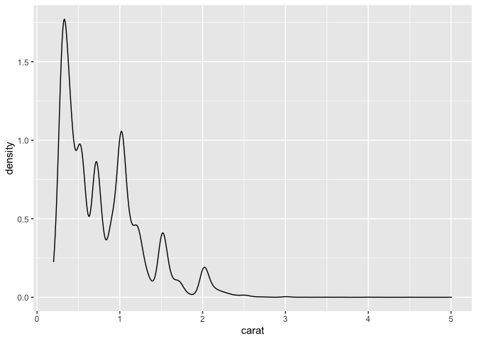

```r
?geom_density

ggplot() +
  geom_density(aes(x=carat), data=diamonds)
```

### 2.2 Change bandwidth/size of the line

- Change the value for “size=” and “adjust=”/“bw=”
- Try size=0.5, 1, 2, etc
- Try adjust=0.2, 1, 3, 6, etc/Try bw = 0.2, 0.1, 0.05, etc
- `adjust`: acts as a multiplier for the default bandwidth. It adjusts the bandwidth proportionally rather than setting it explicitly.
- `bw`: specifies the bandwidth of the kernel, which determines the width of the smoothing window. A smaller `bw` results in a more detailed (less smooth) density curve, while a larger `bw` produces a smoother curve.

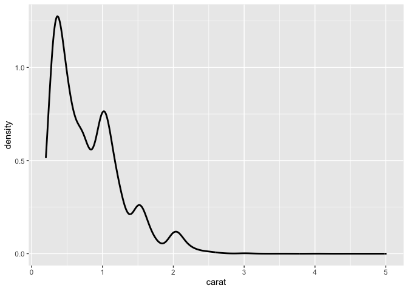

```r
ggplot() +
  geom_density(aes(x=carat), size=1, adjust=2, data=diamonds)
```

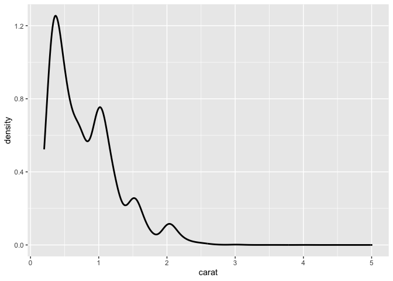

```r
ggplot() +
  geom_density(aes(x=carat), size=1, bw = 0.1, data=diamonds)
```

### 2.3 Stackability

- Using lines instead of bars (e.g. histogram) has the advantage of stackability
- Stackable plots allow for better comparison of cumulative trends or distributions across different categories without overcrowding the plot.

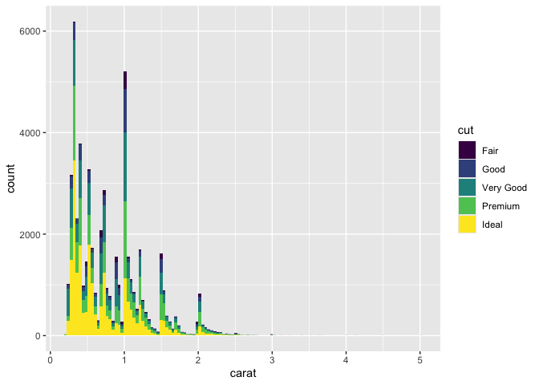

```r
ggplot() +
  geom_histogram(aes(x=carat, fill=cut),
                 bins=120,
                 data=diamonds)
```

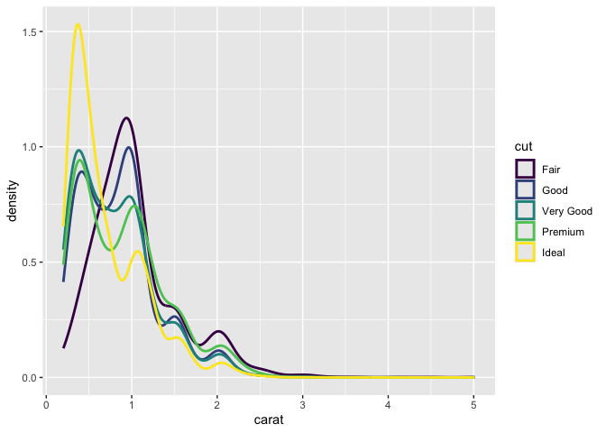

```r
ggplot() +
  geom_density(aes(x=carat, color=cut),
               size=1, adjust=2, data=diamonds)
```

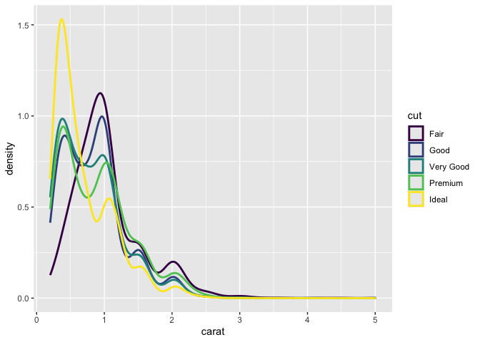

```r
ggplot(data=diamonds, aes(x=carat)) +
  geom_density(aes(color=cut),
               size=1, adjust=2)
```

# 3. Boxplots

## 3.1 Simple boxplot for price

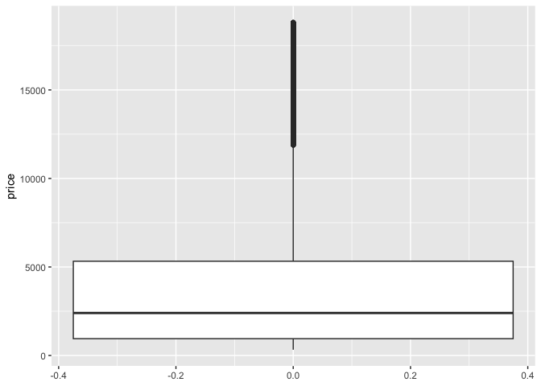

```r
?geom_boxplot
ggplot()+
  geom_boxplot(aes(y=price),data=diamonds)
```

```r
# Median, hinge: (Q1, Q3), whiskers: (Q1-1.5*IQR, Q3+1.5*IQR)
# IQR: interquartile range, IQR=Q3-Q1
# Outliers
```

## 3.2 Side-by-side for each clarity category

### 3.2.1 Map `color`&`fill` to `clarity`

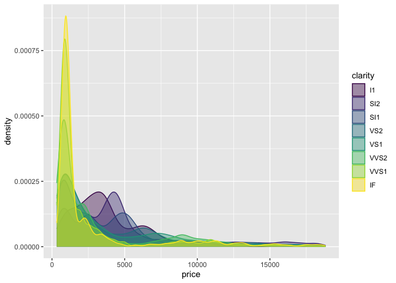

```r
ggplot()+
  geom_density(aes(x=price,color=clarity, fill=clarity),
               alpha = 0.4,
               data=diamonds)
```

### 3.2.2 facet_grid()

- It arranges the facets in a grid based on two categorical variables, one for rows and one for columns.
- You specify the variables for rows and columns using the syntax facet_grid(rows ~ columns).

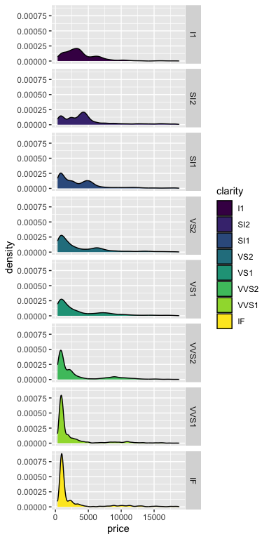

```r
ggplot()+
  geom_density(aes(x=price,fill=clarity),data=diamonds)+
  facet_grid(clarity~.)
```

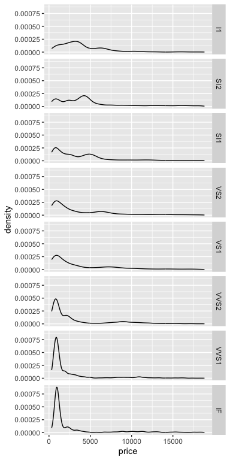

```r
# Here, using `fill=clarity` does not provide any additional information

ggplot()+
  geom_density(aes(x=price),data=diamonds)+
  facet_grid(clarity~.)
```

### 3.2.3 facet_wrap()

- It arranges the facets in a single row or column, wrapping into multiple rows or columns as needed, depending on the number of facets.
- You specify a single categorical variable to facet by, and `facet_wrap` automatically handles the layout, wrapping the facets into multiple rows or columns if necessary.
- You can control the number of rows or columns with the `nrow` or `ncol` arguments.

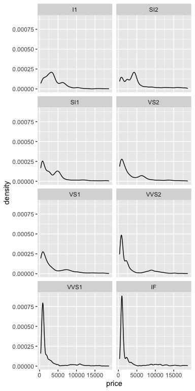

```r
ggplot()+
  geom_density(aes(x=price),data=diamonds)+
  facet_wrap(clarity~., ncol=2)
```

### 3.2.4 Use geom_boxplot()

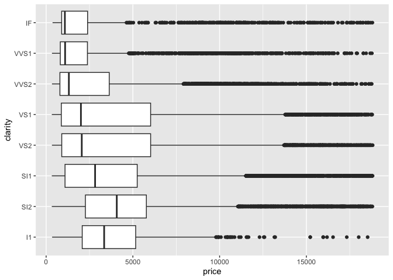

```r
ggplot()+
  geom_boxplot(aes(x=clarity,y=price),data=diamonds)+
  coord_flip()
```

- Any problems with the data?
- Is there an alternative way to view this?
- Dark dot, lines on the top/right hand side.
- not sure the distributions exactly, etc.

## 3.3 Use options

- Change scale, color, fill, shape and size of outlier, orientation, etc

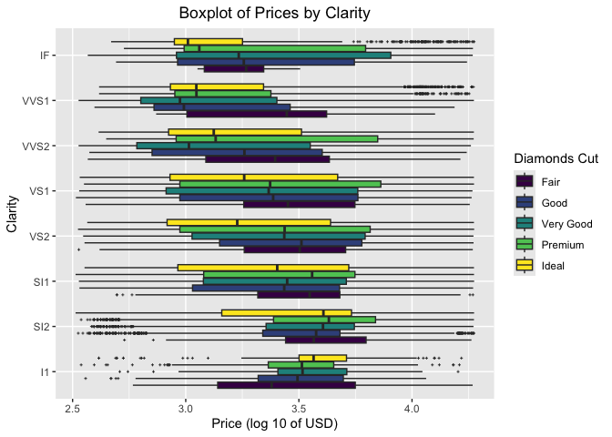

```r
ggplot()+
  geom_boxplot(aes(x=clarity,y=log10(price),
                   fill=cut), outlier.shape = 3,
               outlier.size = 0.2,
               data=diamonds)+
  coord_flip()+
  labs(x="Clarity",
       y="Price (log 10 of USD)",
       fill="Diamonds Cut",
       title="Boxplot of Prices by Clarity")+
  theme(plot.title=element_text(hjust=0.5)) #Center the title
```

- Remove the outliers using `outlier.shape = NA`

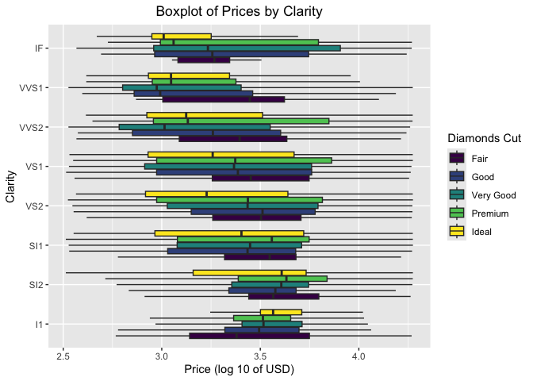

```r
ggplot()+
  geom_boxplot(aes(x=clarity,y=log10(price),
                   fill=cut), outlier.shape = NA,
               data=diamonds)+
  coord_flip()+
  labs(x="Clarity",
       y="Price (log 10 of USD)",
       fill="Diamonds Cut",
       title="Boxplot of Prices by Clarity")+
  theme(plot.title=element_text(hjust=0.5)) #Center the title
```

## 3.4 Advantages and Disadvantages of boxplot

- **Advantage:** view five number summaries very straight forward, makes comparison easy. Allows for quick identification of outliers and the spread of data.
- **Disadvantage:** Not reflect the whole information of the distribution. It may be less useful for datasets with a complex or multi-modal distribution since it summarizes data in a simplified form.

# 4. Violin Plots

- Violin plots are similar to box plots, but they provide more information. In addition to showing the five-number summary (like a box plot), they also display the distribution of the data by showing the kernel density estimation (a smoothed curve) on both sides of the box. This gives a clearer sense of the distribution’s shape, showing where data points are concentrated.
- Violin plots also allow for the visualization of the data’s symmetry or skewness and can show multiple distributions side by side for comparison.
- https://en.wikipedia.org/wiki/Violin_plot
- https://ggplot2.tidyverse.org/reference/geom_violin.html

## 4.1 Intro: geom_violin()

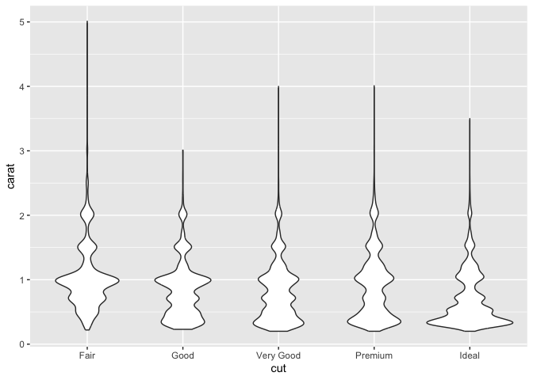

```r
?geom_violin # By default, it only display the mirrored probability density.
ggplot()+
  geom_violin(aes(x=cut,y=carat),data=diamonds)
```

### 4.1.1 Add coord_flip()

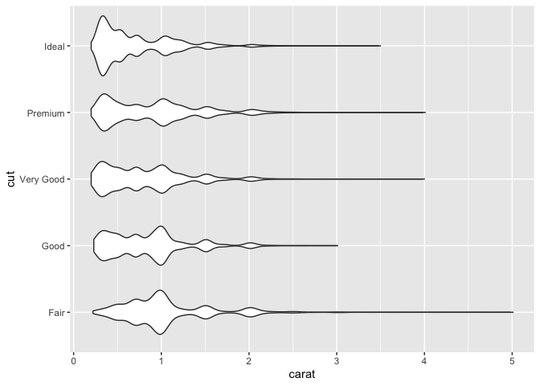

```r
ggplot()+
  geom_violin(aes(x=cut,y=carat),data=diamonds)+
  coord_flip()
```

### 4.1.2 Add more

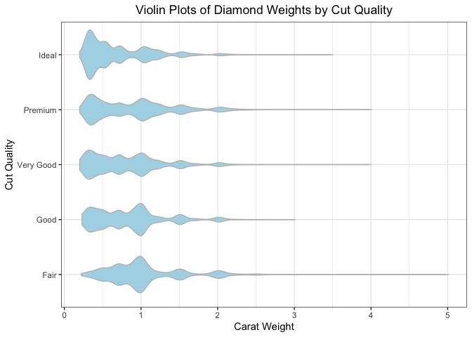

```r
ggplot() +
  geom_violin(aes(x=cut,y=carat),data=diamonds,
              color="grey", fill="lightblue") + #add color and fill
  coord_flip() +
  theme_bw() + #use a complete theme
  labs(x="Cut Quality",
       y="Carat Weight",
       title="Violin Plots of Diamond Weights by Cut Quality") +
  theme(plot.title=element_text(hjust=0.5)) #Center the title
```

```r
# color: controls the color of the border, fill controls what
# fill: controls what color fills the violin
# theme_bw(): change the theme of the background
# The smoothing/adjusting the bandwidth using `bw=`/`adjust=` (similar to the density plot)
```

## 4.2 Combine violins with boxplots

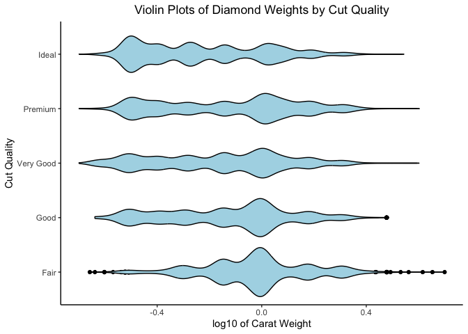

```r
ggplot()+
  geom_boxplot(aes(x=cut,y=log10(carat)),width=.1,
               color="black",fill="white",data=diamonds)+
  geom_violin(aes(x=cut,y=log10(carat)),
              color="black",fill="lightblue",data=diamonds)+
  coord_flip()+
  theme_classic()+
  labs(x="Cut Quality",
       y="log10 of Carat Weight",
       title="Violin Plots of Diamond Weights by Cut Quality") +
  theme(plot.title=element_text(hjust=0.5)) #Center the title
```

```r
# Anything wrong? How to fix it?
```

## 4.3 Other Options

- You can also customize the graph by changing color, scale, fill, etc
- scale_fill_manual() for box plot, bar plot, violin plot, dot plot, etc
- Switch the `geom_boxplot()` and `geom_violin()` layers to display the boxplots on top of the violin plots.

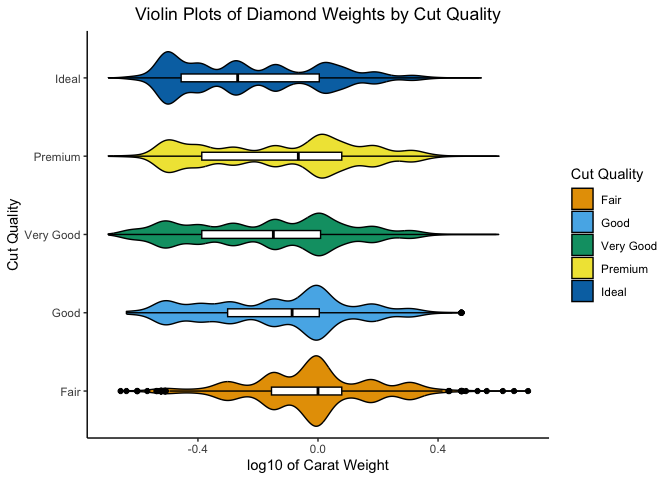

```r
ggplot()+
  geom_violin(aes(x=cut,y=log10(carat),fill=cut),
              color="black",data=diamonds)+
  # Using the `width=` argument will adjust the width of the boxes in the boxplot.
  geom_boxplot(aes(x=cut,y=log10(carat)),width=.1,
               color="black",fill="white",data=diamonds)+
  coord_flip()+
  theme_classic()+
  labs(x="Cut Quality",
       y="log10 of Carat Weight",
       fill="Cut Quality",
       title="Violin Plots of Diamond Weights by Cut Quality") +
  theme(plot.title=element_text(hjust=0.5)) +
  scale_fill_manual(values = c("#E69F00", "#56B4E9", "#009E73",
                               "#F0E442", "#0072B2"))
```

```r
# Although the colors do not provide any additional information here!
```